# Assignment 2

## Andres Arias

### Z23987588

```python
import pandas as pd
import numpy as np
import matplotlib.pyplot as plt
import networkx as nx
import random
import ast

# Same subsample as Project Part #1, BFS from a random seed node, first 5000 nodes
path_edges = '/Users/andresarias/Documents/FAU/SocialNetworks_BigData/Assignment_1/data/edges.csv'
path_nodes = '/Users/andresarias/Documents/FAU/SocialNetworks_BigData/Assignment_1/data/nodes.csv'

edges = pd.read_csv(path_edges)
nodes = pd.read_csv(path_nodes)

G = nx.from_pandas_edgelist(edges, source='id_0', target='id_1')

random.seed(42)
start_node = random.choice(list(G.nodes))
bfs_tree = nx.bfs_tree(G, source=start_node)
sample_nodes = list(bfs_tree.nodes)[:5000]
G_sample = G.subgraph(sample_nodes).copy()

# Drop duplicates in the nodes dataset
nodes_unique = nodes.drop_duplicates(subset='spotify_id', keep='first')
id_to_name = dict(zip(nodes_unique['spotify_id'], nodes_unique['name']))

print("Start node:", start_node)
print(G_sample)
```

```
Start node: 2Z1nXVYB6tke5IsWSLI7lw
Graph with 5000 nodes and 22836 edges
```

## 1. Compute degree centrality for all nodes

```python
degree_centrality = nx.degree_centrality(G_sample)

print("Degree centrality computed for", len(degree_centrality), "nodes")
print("Some of them", list(degree_centrality.items())[:2])
```

```
Degree centrality computed for 5000 nodes
Some of them [('56EYDRc4IlffrNZyE5vtOx', 0.00020004000800160032), ('4PhdYoQGH8s1xee81dqQOO', 0.000600120024004801)]
```

```python
degree_centrality
```

[output not shown]

[output cut: 946 more lines]

[output not shown]

## 2. Print out the top 10 ARTIST NAMES (not node ids) with the highest degree centrality

```python
# Degree centrality is a dictionary, so i will use .items() to obtain key:value with an iteration
# sort to order all the data collection and key=lambda x: x[1] to order by values and not with keys (IDs)
top10_degree = sorted(degree_centrality.items(), key=lambda x: x[1], reverse=True)[:10]

print("Top 10 artists by degree centrality")
for i, (node_id, score) in enumerate(top10_degree, start=1): # enumerate to avoid creating a counter
    print((i, id_to_name[node_id], score))
```

```
Top 10 artists by degree centrality
(1, 'Yellow Claw', 0.041408281656331265)
(2, 'The Partysquad', 0.03540708141628326)
(3, 'Kempi', 0.034206841368273656)
(4, 'Bizzey', 0.027405481096219243)
(5, 'Adje', 0.027005401080216044)
(6, 'Gunna', 0.026405281056211243)
(7, 'Steve Aoki', 0.024004800960192037)
(8, 'French Montana', 0.023404680936187236)
(9, 'Ali B', 0.022804560912182435)
(10, 'R3HAB', 0.022604520904180837)
```

## 3. Compute betweenness centrality for all nodes

```python
betweenness_centrality = nx.betweenness_centrality(G_sample)

print("Betweenness centrality computed for", len(betweenness_centrality), "nodes")
# Same as the last cell, .items to print key and value of the dictionary
print("Example:", list(betweenness_centrality.items())[:2])
```

```
Betweenness centrality computed for 5000 nodes
Example: [('56EYDRc4IlffrNZyE5vtOx', 0.0), ('4PhdYoQGH8s1xee81dqQOO', 7.436732641970365e-05)]
```

## 4. Print out the top 10 ARTIST NAMES (not node ids) with the highest betweenness centrality

```python
top10_betweenness = sorted(betweenness_centrality.items(), key=lambda x: x[1], reverse=True)[:10]

print("Top 10 artists by betweenness")
for i, (node_id, score) in enumerate(top10_betweenness, start=1): # enumerate to avoid creating a counter
    print(i, id_to_name[node_id], score)
```

```
Top 10 artists by betweenness
1 Murda 0.06585476765089478
2 Adje 0.05806965693192295
3 Yellow Claw 0.05342999454117437
4 3robi 0.05006783617494373
5 The Partysquad 0.04833986010723205
6 Dopebwoy 0.04247419463745001
7 Kempi 0.03944786322008193
8 Sevn Alias 0.03891265654749639
9 Bizzey 0.036077173028878536
10 Ali B 0.03584641606244379
```

## 5. Compute closeness centrality for all nodes

```python
closeness_centrality = nx.closeness_centrality(G_sample)

print("Closeness centrality computed for", len(closeness_centrality), "nodes")
# Same as the last cell, .items to print key and value of the dictionary
print("Example:", list(closeness_centrality.items())[:2])
```

```
Closeness centrality computed for 5000 nodes
Example: [('56EYDRc4IlffrNZyE5vtOx', 0.2415909530253238), ('4PhdYoQGH8s1xee81dqQOO', 0.22965957642302567)]
```

## 6. Print out the top 10 ARTIST NAMES (not node ids) with the highest closeness centrality

```python
top10_closeness = sorted(closeness_centrality.items(), key=lambda x: x[1], reverse=True)[:10]

print("Top 10 artists by closeness")
for i, (node_id, score) in enumerate(top10_closeness, start=1): # enumerate to avoid creating a counter
    print(i, id_to_name[node_id], score)
```

```
Top 10 artists by closeness
1 Adje 0.38673990406931763
2 Bizzey 0.374821923970908
3 Josylvio 0.37342197654440873
4 Dopebwoy 0.3731710958495073
5 Murda 0.36950255007761107
6 Sevn Alias 0.36827758950935613
7 Jonna Fraser 0.3677357657790202
8 3robi 0.36695294722161054
9 Ali B 0.36494378741422107
10 The Partysquad 0.364411721825339
```

## 7. Compute eigenvector centrality for all nodes

```python
eigenvector_centrality = nx.eigenvector_centrality(G_sample)

print("Eigenvector centrality computed for", len(eigenvector_centrality), "nodes")
# Same as the last cell, .items to print key and value of the dictionary
print("Example:", list(eigenvector_centrality.items())[:2])
```

```
Eigenvector centrality computed for 5000 nodes
Example: [('56EYDRc4IlffrNZyE5vtOx', 0.00024217922162569796), ('4PhdYoQGH8s1xee81dqQOO', 0.00015774352879059945)]
```

## 8. Print out the top 10 ARTIST NAMES (not node ids) with the highest eigenvector centrality

```python
top10_eigenvector = sorted(eigenvector_centrality.items(), key=lambda x: x[1], reverse=True)[:10]

print("Top 10 artists by eigenvector")
for i, (node_id, score) in enumerate(top10_eigenvector, start=1): # enumerate to avoid creating a counter
    print(i, id_to_name[node_id], score)
```

```
Top 10 artists by eigenvector
1 Young Thug 0.16602393893499662
2 Future 0.16399595950475235
3 French Montana 0.16294141763961173
4 Ty Dolla $ign 0.16182650284856248
5 Gucci Mane 0.1594126337924293
6 2 Chainz 0.15229185775230147
7 Lil Wayne 0.1522095150669189
8 Chris Brown 0.1518297367124981
9 Tyga 0.1442466002740732
10 Gunna 0.1390873448896142
```

## 9. Compute PageRank scores for all nodes

```python
pagerank = nx.pagerank(G_sample)

print("PageRank computed for", len(pagerank), "nodes")
print("Example:", list(pagerank.items())[:2])
```

```
PageRank computed for 5000 nodes
Example: [('56EYDRc4IlffrNZyE5vtOx', 5.537761572933791e-05), ('4PhdYoQGH8s1xee81dqQOO', 0.00012860516427527034)]
```

## 10. Print out the top 10 ARTIST NAMES (not node ids) with the highest PageRank values.

```python
top10_pagerank = sorted(pagerank.items(), key=lambda x: x[1], reverse=True)[:10]

print("Top 10 artists by pagerank")
for i, (node_id, score) in enumerate(top10_pagerank, start=1):
    print(i, id_to_name[node_id], score)
```

```
Top 10 artists by pagerank
1 Kempi 0.005467647213726697
2 NAZAAR 0.005235644688338895
3 The Partysquad 0.005118065047359622
4 Yellow Claw 0.005038979536910165
5 Afro Bros 0.0032820358300347996
6 Ali B 0.0032751546672941984
7 Bizzey 0.0032505468799369024
8 Adje 0.0032473122987943773
9 Lange Frans 0.0028827937784011138
10 Mario Cash 0.002871849322152917
```

## 11. Add a markdown cell answering the following question: what do you observe when comparing the top 10 nodes across all centrality measures and PageRank?

- There are 4 artists that appear in 4/5 top 10 lists (The Partysquad, Bizzey, Adje, Ali B) And these 4 four didn't appear in the eigenvector list.
- 2 artists appeared in 3/5 lists (Yellow Claw, Kempi).
- 6 artists appeared just in 2/5 lists.
- 16 artists just appeared in one list! 8 of them just in eigenvector (Young Thug, Future, Gucci Mane, Lil Wayne, Tyga, 2 Chainz, Ty Dolla $ign, Chris Brown), 4 just in PageRank (NAZAAR, Lange Frans, Mario Cash, Afro Bros), 2 just in closeness (Josylvio, Jonna Fraser) and 2 just degree (Steve Aoki, R3HAB).

Results show that eigenvector identifies a different set of influential artists, as all four artists appearing in 4/5 lists are absent from its ranking, while 8 artists appear exclusively in the eigenvector list.

This is because eigenvector centrality considers the importance of an artists collaborators rather than simply the number or structure of their connections.

Curiosly no artist appears in all five top 10 lists, suggesting that the five centrality measures capture different aspects of importance and are not redundant!

## 12. Plot a histogram of each computed variable (degree centrality, betweenness centrality, closeness centrality, eigenvector centrality, and PageRank

## 13. Under each histogram, add a markdown cell describing what you observe

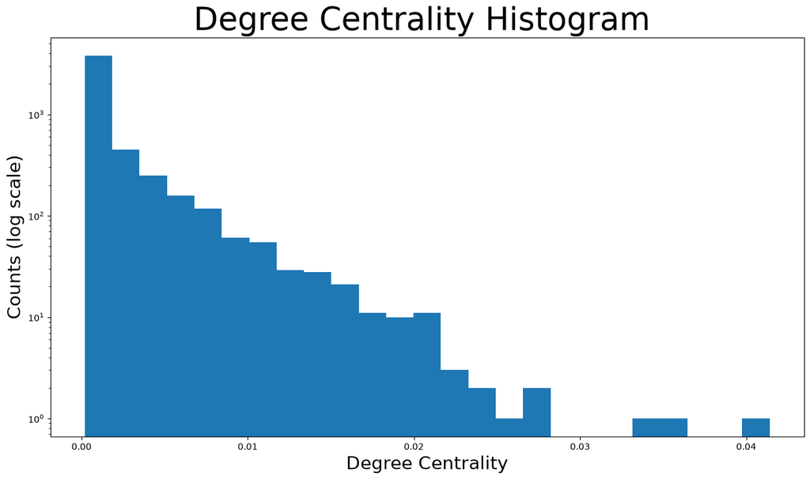

```python
# 12.1 Degree centrality - Code taken from course slides
plt.figure(figsize=(15, 8))
plt.hist(degree_centrality.values(), bins=25)
plt.yscale('log')  # the distribution is very skewed, 75.8% of artists fall in the first bin
plt.title("Degree Centrality Histogram ", fontdict={"size": 35}, loc="center")
plt.xlabel("Degree Centrality", fontdict={"size": 20})
plt.ylabel("Counts (log scale)", fontdict={"size": 20})
```

The distribution shows a clear decreasing pattern, indicating that most artists have relatively few connections compared with a small number of highly connected artists. The distribution decreases constant until approximately 0.028, followed by a gap and three isolated observations around 0.034 0.035 and 0.041, corresponding to Kempi and Yellow Claw. These could be outliers, but is just a suspicion, it depends of the analysis

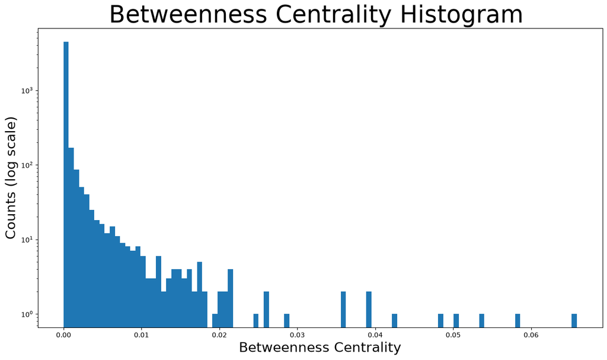

```python
# 12.2 Betweenness centrality - Code taken from course slides
plt.figure(figsize=(15, 8))
plt.hist(betweenness_centrality.values(), bins=100)
plt.yscale('log')
plt.title("Betweenness Centrality Histogram ", fontdict={"size": 35}, loc="center")
plt.xlabel("Betweenness Centrality", fontdict={"size": 20})
plt.ylabel("Counts (log scale)", fontdict={"size": 20})
```

Betweenness exhibits the most extreme concentration with a large part of artists having a value of exactly zero, meaning they do not act as intermediaries along shortest paths between other nodes.

Distribution then decreases rapidly, forming a long, sparse tail with isolated artists reaching approximately 0.06

Furthermore, top 50 artists account for 40.3% of the total betweenness centrality. Taht indicate that a small number of artists play a disproportionately important role in connecting different parts of the graph

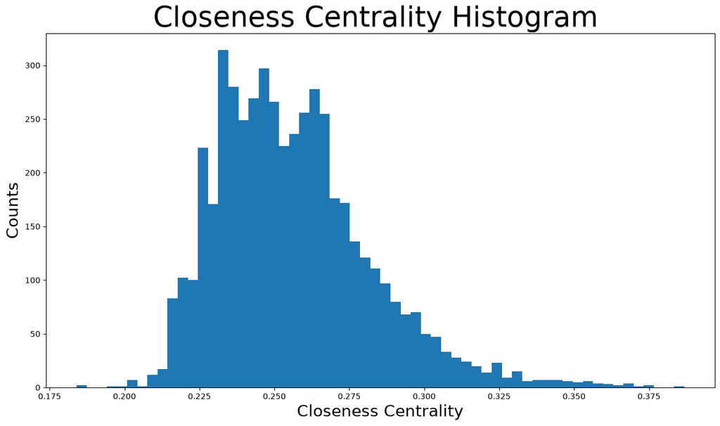

```python
# 12.3 Closeness centrality - Code taken from course slides
plt.figure(figsize=(15, 8))
plt.hist(closeness_centrality.values(), bins=60)
plt.title("Closeness Centrality Histogram ", fontdict={"size": 35}, loc="center")
plt.xlabel("Closeness Centrality", fontdict={"size": 20})
plt.ylabel("Counts", fontdict={"size": 20})
```

Closeness centrality displays a clear, approximately bell shaped distribution with its highest concentration around 0.233 and a slight right skew extending to approximately 0.387.

The values are concentrated within a relatively narrow range, suggesting that most artists have similar overall accessibility to other nodes. The absence of values close to zero is consistent with the networks connected structure, while the average shortest path distance of 3.93 observed in Part 1 supports the interpretation of a relatively short distance, small world network.

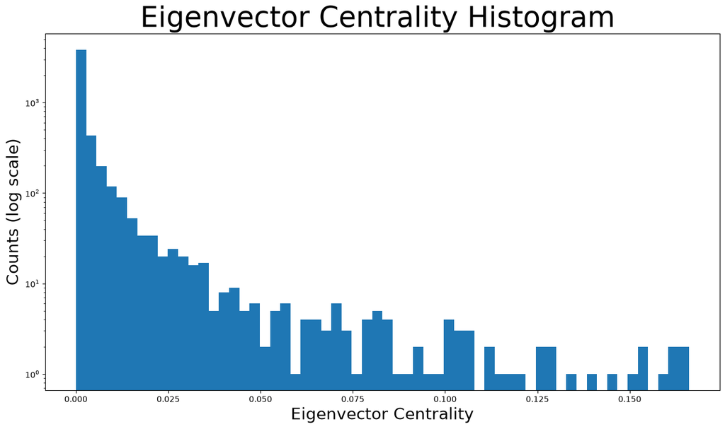

```python
# 12.4 Eigenvector centrality - Code taken from course slides
plt.figure(figsize=(15, 8))
plt.hist(eigenvector_centrality.values(), bins=60)
plt.yscale('log')
plt.title("Eigenvector Centrality Histogram ", fontdict={"size": 35}, loc="center")
plt.xlabel("Eigenvector Centrality", fontdict={"size": 20})
plt.ylabel("Counts (log scale)", fontdict={"size": 20})
```

Eigenvector exhibits a decreasing distribution similar to degree centrality, but with a more continuously populated upper tail extending to approx 0.166.

Instead than having only a few isolated high value observations, several artists occupy intermediate and high positions throughout this tail.

This pattern is consistent with a group of influential artists, who are connected to one another and therefore receive high scores because of the importance of their collaborators, not simply the number of connections they have, main idea of eigenvector.

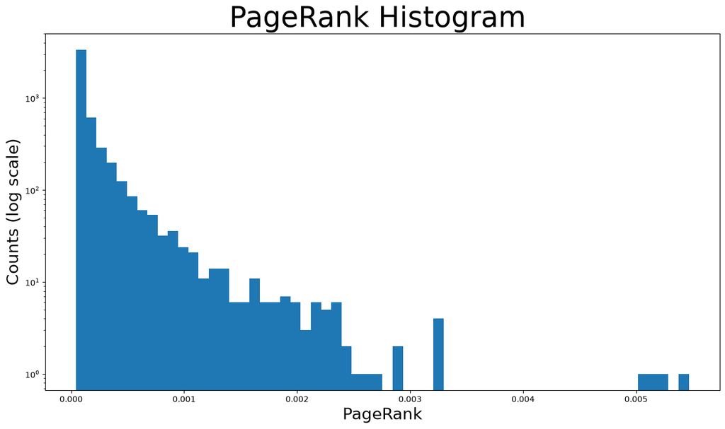

```python
# 12.5 PageRank
plt.figure(figsize=(15, 8))
plt.hist(pagerank.values(), bins=60)
plt.yscale('log')
plt.title("PageRank Histogram ", fontdict={"size": 35}, loc="center")
plt.xlabel("PageRank", fontdict={"size": 20})
plt.ylabel("Counts (log scale)", fontdict={"size": 20})
```

PageRank shows a steeply decreasing distribution, broadly resembling degree centrality, followed by a small number of artists with substantially higher scores.

A group of four artists (Afro Bros, Ali B, Bizzey and Adje) forms a distinct peak around 0.0033, while a few additional artists occupy the highest values as I show in the top 10 point for this

Aditionally PageRank values are small because the total score is normalized to 1 across 5,000 artists (maximum = 0.00547). Its distribution strongly resembles degree centrality (Spearman = 0.949), but PageRank distributes each artist’s score among their neighbors, unlike eigenvector centrality. This difference explains why top 10 lists are not sharing artists

## 14. Create boxplots comparing centralities and PageRank values between artists whose popularity is >=50, and artists whose popularity is < 50

```python
# Join the centrality measures with popularity from the nodes dataset
central = pd.DataFrame({        # The five centrality measures are dictionaries {spotify_id: score}
    'degree': pd.Series(degree_centrality),   # pd.Series turns each one into a column indexed by spotify_id, so they all align on the same artist
    'betweenness': pd.Series(betweenness_centrality),
    'closeness': pd.Series(closeness_centrality),
    'eigenvector': pd.Series(eigenvector_centrality),
    'pagerank': pd.Series(pagerank),
})
central
```

|  | degree | betweenness | closeness | eigenvector | pagerank |
| --- | --- | --- | --- | --- | --- |
| 56EYDRc4IlffrNZyE5vtOx | 0.000200 | 0.000000 | 0.241591 | 0.000242 | 0.000055 |
| 4PhdYoQGH8s1xee81dqQOO | 0.000600 | 0.000074 | 0.229660 | 0.000158 | 0.000129 |
| 6NtaAGerS1mblEJLOVyplc | 0.000200 | 0.000000 | 0.231521 | 0.000073 | 0.000050 |
| 3LKyKP6I4FwzbEzjcDn4H3 | 0.000200 | 0.000000 | 0.225099 | 0.000104 | 0.000056 |
| 4zYX8Aa744hQ5O2hpAYQI3 | 0.001600 | 0.000152 | 0.290454 | 0.005896 | 0.000167 |
| ... | ... | ... | ... | ... | ... |
| 6WBf0WXqyBkCCYAEPUeDxn | 0.001600 | 0.000040 | 0.254363 | 0.000978 | 0.000149 |
| 3l1C23aRp4lfkBK3lLAp2m | 0.004601 | 0.000418 | 0.276112 | 0.009462 | 0.000355 |
| 1KAvgimTLG9YZew4b9B4bG | 0.000600 | 0.000003 | 0.271140 | 0.003901 | 0.000077 |
| 491U1PrV1EoQuhM0aUCn9r | 0.006801 | 0.004224 | 0.297701 | 0.012101 | 0.000665 |
| 1x9jsneK4s5y78brOgg3Ps | 0.000200 | 0.000000 | 0.267098 | 0.000830 | 0.000055 |

5000 rows × 5 columns

```python
# The index holds the spotify_id, I move it into a column to be able to merge on it
central.index.name = 'spotify_id'
central = central.reset_index()

# popularity and followers live in the nodes dataset, not in the graph.
central = central.merge(
    nodes_unique[['spotify_id', 'name', 'popularity', 'followers']], #dropping duplicates
    on='spotify_id',
    how='left')

# merge must keep exactly 5000 rows and leave no missing popularity
print("Missing popularity:", central['popularity'].isna().sum())
print("Missing followers:", central['followers'].isna().sum())

# Split the artists in two groups by the popularity
high = central[central['popularity'] >= 50]
low = central[central['popularity'] < 50]

print("Artists with popularity >= 50:", len(high))
print("Artists with popularity <  50:", len(low))
```

```
Missing popularity: 0
Missing followers: 0
Artists with popularity >= 50: 1310
Artists with popularity <  50: 3690
```

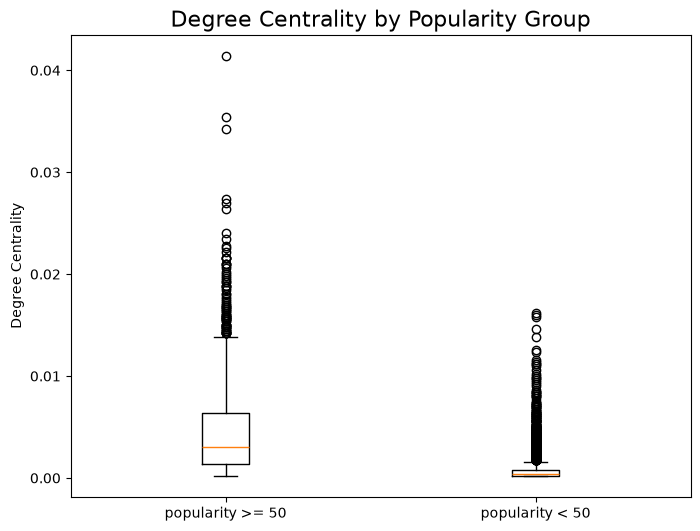

```python
# 14.1 Degree centrality
plt.figure(figsize=(8, 6))
plt.boxplot([high['degree'], low['degree']],
            tick_labels=['popularity >= 50', 'popularity < 50'])
plt.title("Degree Centrality by Popularity Group", fontdict={"size": 16})
plt.ylabel("Degree Centrality")
plt.show()
```

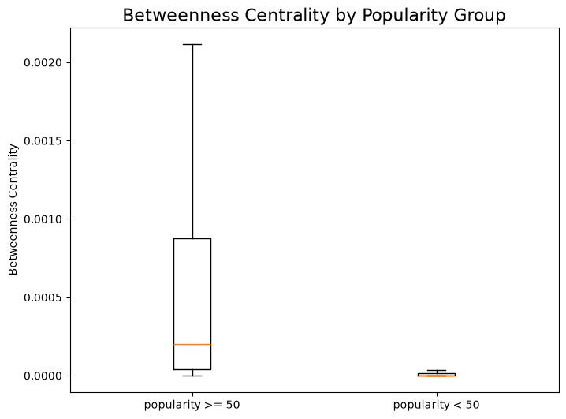

```python
# 14.2 Betweenness centrality
plt.figure(figsize=(8, 6))
plt.boxplot([high['betweenness'], low['betweenness']],
            tick_labels=['popularity >= 50', 'popularity < 50'],
            showfliers=False) # showfliers = False because outliers reach 0.066 and flatten both boxes against the axis
plt.title("Betweenness Centrality by Popularity Group", fontdict={"size": 16})
plt.ylabel("Betweenness Centrality")
plt.show()
```

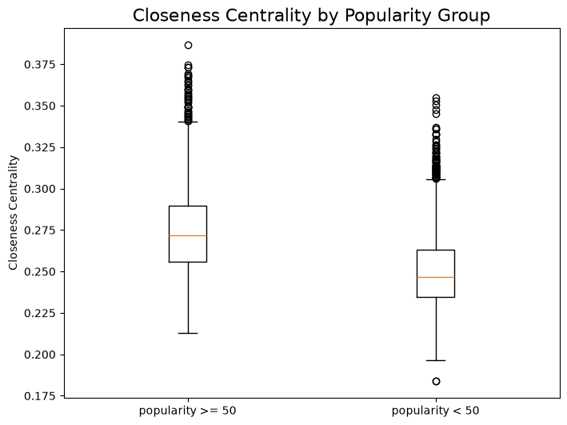

```python
# 14.3 Closeness centrality
plt.figure(figsize=(8, 6))
plt.boxplot([high['closeness'], low['closeness']],
            tick_labels=['popularity >= 50', 'popularity < 50'])
plt.title("Closeness Centrality by Popularity Group", fontdict={"size": 16})
plt.ylabel("Closeness Centrality")
plt.show()
```

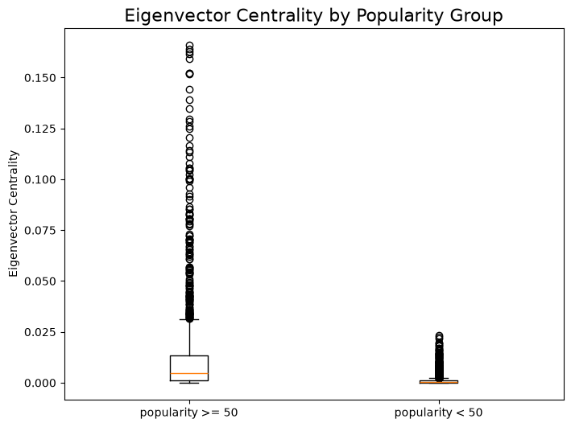

```python
# 14.4 Eigenvector centrality
plt.figure(figsize=(8, 6))
plt.boxplot([high['eigenvector'], low['eigenvector']],
            tick_labels=['popularity >= 50', 'popularity < 50'])
plt.title("Eigenvector Centrality by Popularity Group", fontdict={"size": 16})
plt.ylabel("Eigenvector Centrality")
plt.show()
```

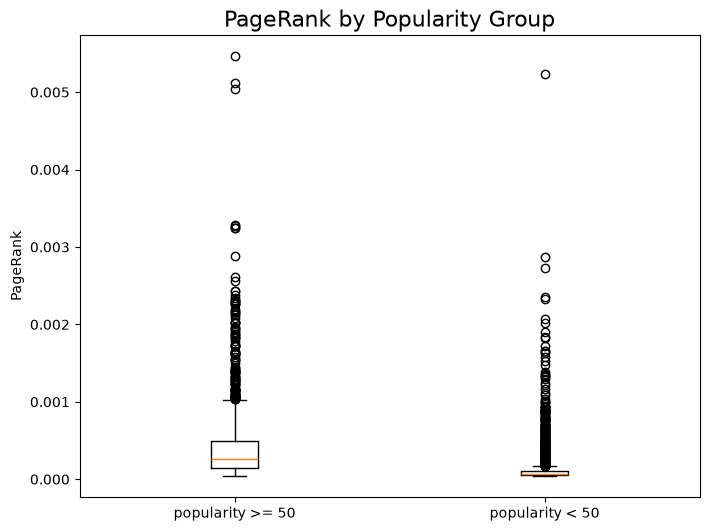

```python
# 14.5 PageRank
plt.figure(figsize=(8, 6))
plt.boxplot([high['pagerank'], low['pagerank']],
            tick_labels=['popularity >= 50', 'popularity < 50'])
plt.title("PageRank by Popularity Group", fontdict={"size": 16})
plt.ylabel("PageRank")
plt.show()
```

Ref: https://pandas.pydata.org/docs/reference/api/pandas.Series.html

Ref: https://pandas.pydata.org/docs/user_guide/dsintro.html#series

Ref: https://pandas.pydata.org/docs/reference/api/pandas.DataFrame.merge.html

Ref: https://pandas.pydata.org/docs/user_guide/merging.html

## 15. Add a markdown cell and explain what you observe under each plot. Hint: Are popular artists also more central/influential?

I used AI to create this summary to help me answer this point

```python
# Summary of the two groups for each measure
measures = ['degree', 'betweenness', 'closeness', 'eigenvector', 'pagerank']

print("%-14s %13s %13s %8s" % ("measure", "median >=50", "median <50", "ratio"))
for mea in measures:
    a, b = high[mea].median(), low[mea].median()
    ratio = "inf" if b == 0 else "%.1fx" % (a / b)
    print("%-14s %13.3e %13.3e %8s" % (mea, a, b, ratio))
```

```
measure          median >=50    median <50    ratio
degree             3.001e-03     4.001e-04     7.5x
betweenness        2.020e-04     0.000e+00      inf
closeness          2.719e-01     2.468e-01     1.1x
eigenvector        4.742e-03     3.760e-04    12.6x
pagerank           2.573e-04     6.695e-05     3.8x
```

```python
# Numbers behind the boxplots: quartiles, overlap between groups and correlation
measures = ['degree', 'betweenness', 'closeness', 'eigenvector', 'pagerank']

for mea in measures:
    a, b = high[mea], low[mea]
    print("###", mea.upper())
    print("  >= 50 : Q1 %.3e   median %.3e   Q3 %.3e" % (a.quantile(.25), a.median(), a.quantile(.75)))
    print("  <  50 : Q1 %.3e   median %.3e   Q3 %.3e" % (b.quantile(.25), b.median(), b.quantile(.75)))
    # How much the two groups overlap: if the measure separated them perfectly, both would be 0%
    print("  %% of <50 above the median of >=50: %.1f%%" % ((b > a.median()).mean() * 100))
    print("  %% of >=50 below the median of <50: %.1f%%" % ((a < b.median()).mean() * 100))
    print("  Spearman correlation with popularity: %.3f"
          % central['popularity'].corr(central[mea], method='spearman'))
    print()

# Betweenness is the only measure with exact zeros, so I count them per group
print("Artists with betweenness exactly 0:")
print("  >= 50 : %.1f%%" % ((high['betweenness'] == 0).mean() * 100))
print("  <  50 : %.1f%%" % ((low['betweenness'] == 0).mean() * 100))
```

```
### DEGREE
  >= 50 : Q1 1.400e-03   median 3.001e-03   Q3 6.401e-03
  <  50 : Q1 2.000e-04   median 4.001e-04   Q3 8.002e-04
  % of <50 above the median of >=50: 5.3%
  % of >=50 below the median of <50: 2.5%
  Spearman correlation with popularity: 0.774

### BETWEENNESS
  >= 50 : Q1 3.908e-05   median 2.020e-04   Q3 8.741e-04
  <  50 : Q1 0.000e+00   median 0.000e+00   Q3 1.387e-05
  % of <50 above the median of >=50: 8.5%
  % of >=50 below the median of <50: 0.0%
  Spearman correlation with popularity: 0.716

### CLOSENESS
  >= 50 : Q1 2.559e-01   median 2.719e-01   Q3 2.899e-01
  <  50 : Q1 2.344e-01   median 2.468e-01   Q3 2.630e-01
  % of <50 above the median of >=50: 14.1%
  % of >=50 below the median of <50: 13.2%
  Spearman correlation with popularity: 0.466

### EIGENVECTOR
  >= 50 : Q1 1.357e-03   median 4.742e-03   Q3 1.337e-02
  <  50 : Q1 1.444e-04   median 3.760e-04   Q3 9.948e-04
  % of <50 above the median of >=50: 4.8%
  % of >=50 below the median of <50: 10.0%
  Spearman correlation with popularity: 0.617

### PAGERANK
  >= 50 : Q1 1.404e-04   median 2.573e-04   Q3 4.914e-04
  <  50 : Q1 5.492e-05   median 6.695e-05   Q3 1.034e-04
  % of <50 above the median of >=50: 6.8%
  % of >=50 below the median of <50: 4.0%
  Spearman correlation with popularity: 0.704

Artists with betweenness exactly 0:
  >= 50 : 5.1%
  <  50 : 59.3%
```

### 15.1 Degree Centrality

The Q3 of the low popularity group (8.00e-04) is below the Q1 of the high popularity group (1.40e-03). The boxes do not overlap, meaning that 75% of non popular artists have fewer connections than the least connected 25% of popular artists. Only 5.3% of artists with popularity below 50 exceed the median degree of the high popularity group

### 15.2 Betweenness Centrality

Nearly six out of ten non popular artists do not lie on any shortest paths between other nodes, compared with only one in twenty popular artists.

Consequently, the median and Q1 of the low popularity group are both zero, compressing its box against the horizontal axis. I used showfliers=False to hide outliers and improve readability, since extreme values would otherwise make the differences between the groups harder to observ

### 15.3 Closeness Centrality

Closeness is the exception h3re. The ratio between group medians is only 1.1×, and its Spearman correlation with popularity is the lowest (0.466).

The boxes overlap considerably with 14.1% of non popular artists exceed the median of popular artists, while 13.2% of popular artists fall below the median of noncpopular artists.

This suggests that popularity doesnt necessarily mean being closer to other artists. As observed in the closeness histogram, most nodes are within a relatively narrow range of distances, leaving less room for popular artists to distinguish themselves

### 15.4 Eigenvector Centrality

This one shows the largest difference between groups with a median ratio of 12.6×. However, 10.0% of popular artists fall below the median of non popular artists, compared with only 2.5% for degree centrality.

It indicates that some popular artists have very low eigenvector scores. An artist can be popular without collaborating with highly connected artists, so, maybe it proves that popularity and structural influence are not the same

### 15.5 PageRank

It shows an intermediate difference between groups with a median ratio of 3.8×, lower than degree centrality (7.5×), despite their strong correlation (Spearman = 0.949).

Unlike eigenvector centrality, PR can reward artists whose collaborators have few other connections. For example, NAZAAR has 57 neighbors, 54 of whom have degree 1, meaning they contribute their entire score exclusively to him.

Finally, PR correlation with popularity is 0.704, compared with 0.774 for degree centrality.

Ref: https://pandas.pydata.org/docs/reference/api/pandas.DataFrame.corr.html

## 16. Apply the Louvain community detection algorithm. Report the number of obtained communities.

```python
communities = nx.community.louvain_communities(G_sample, seed=42)

print("Number of communities:", len(communities))
```

```
Number of communities: 16
```

## 17. Calculate community sizes and print them

```python
community_sizes = [len(c) for c in communities]

print("Community sizes:")
for i, size in enumerate(community_sizes):
    print("  Community %2d: %4d artists" % (i, size))

print()
print("Total artists:", sum(community_sizes))
print("Largest community:", max(community_sizes))
print("Smallest community:", min(community_sizes))
```

```
Community sizes:
  Community  0:  402 artists
  Community  1:   12 artists
  Community  2:   21 artists
  Community  3:  549 artists
  Community  4:   42 artists
  Community  5: 1614 artists
  Community  6:   84 artists
  Community  7:    3 artists
  Community  8:  243 artists
  Community  9:  533 artists
  Community 10:   27 artists
  Community 11:  765 artists
  Community 12:   39 artists
  Community 13:   56 artists
  Community 14:  290 artists
  Community 15:  320 artists

Total artists: 5000
Largest community: 1614
Smallest community: 3
```

## 18. Compute the average popularity and average # followers per community and create two bar charts showing the average values per community (2 points). One bar chart is for plotting average popularity against community labels, and the other is for plotting average # followers against community labels

```python
# Average popularity and followers per community
# Map every artist to its community label
community_of = {}
for i, c in enumerate(communities):
    for node in c:
        community_of[node] = i

# Add the label to the table built in step 14 and average by community
central['community'] = central['spotify_id'].map(community_of)
by_comm = central.groupby('community').agg(
    artists=('spotify_id', 'size'),
    avg_popularity=('popularity', 'mean'),
    avg_followers=('followers', 'mean'))

print(by_comm.round(2))
```

```
           artists  avg_popularity  avg_followers
community
0              402           43.14      257628.98
1               12           15.00       32308.83
2               21            5.81        2416.52
3              549           41.62      434634.44
4               42           28.24       28442.52
5             1614           23.57       20118.32
6               84           45.77      185673.36
7                3           28.33        1964.00
8              243           25.34       30100.86
9              533           38.63      312898.96
10              27            7.00         405.19
11             765           36.42      619431.71
12              39           33.33      599293.00
13              56           19.55        5115.95
14             290           59.35     3839277.88
15             320           38.43      964921.18
```

- groupby + agg: https://pandas.pydata.org/docs/reference/api/pandas.core.groupby.DataFrameGroupBy.agg.html
- Mapping nodes to community labels is not covered in the course notebooks, I tried with AI and some sources to understand how to built this
- the Louvain output is a list of sets, so I flatten it into a {node: label} dictionary first

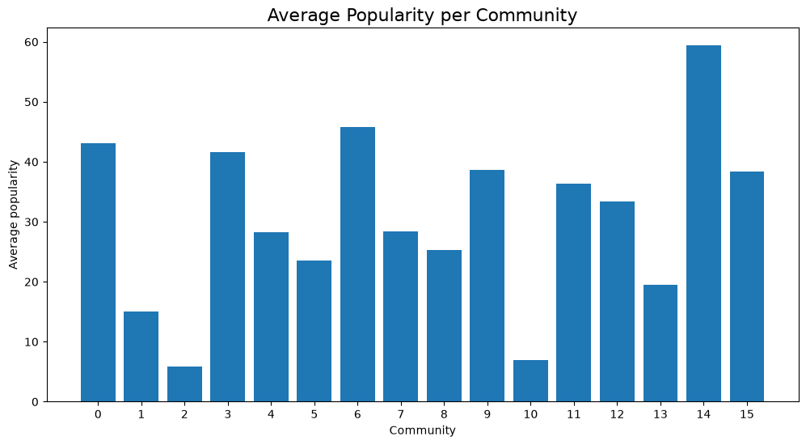

```python
# Average popularity per community
plt.figure(figsize=(12, 6))
plt.bar(by_comm.index, by_comm['avg_popularity'])
plt.title("Average Popularity per Community", fontdict={"size": 16})
plt.xlabel("Community")
plt.ylabel("Average popularity")
plt.xticks(by_comm.index)
plt.show()
```

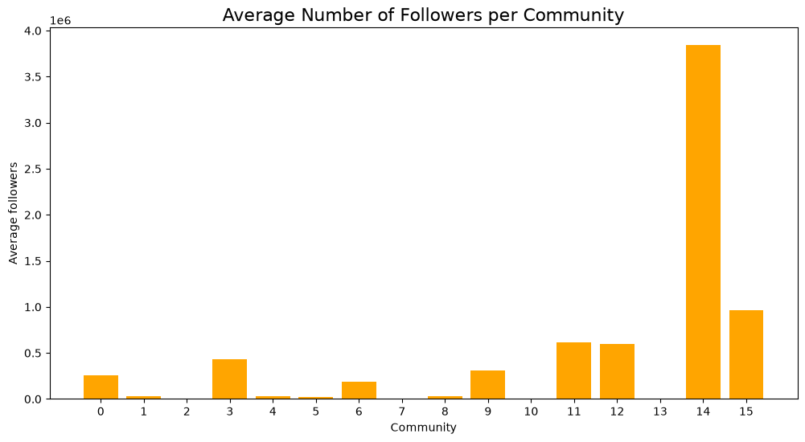

```python
# Average number of followers per community
plt.figure(figsize=(12, 6))
plt.bar(by_comm.index, by_comm['avg_followers'], color='orange')
plt.title("Average Number of Followers per Community", fontdict={"size": 16})
plt.xlabel("Community")
plt.ylabel("Average followers")
plt.xticks(by_comm.index)
plt.show()
```

## 19. Add a markdown cell after each plot and describe what you observe

The bar chart shows substantial differences in average popularity across communities. Comm 14 has the highest average popularity (59.35), followed by commu 6 (45.77) and comm 0 (43.14).

In contrast, communities 10 (7.00) and 2 (5.81) have the lowest values. Interestingly, community 5 is the largest, with 1,614 artists (approximately 32% of the sample), yet its average popularity is relatively low (23.57).

It indicates that **community size does not necessarily reflect artist popularity**

The followers chart reveals substantial differences in audience size across communities. Community 14 has the highest average number of followers, while community 10 has the lowest.

Popularity and follower counts dont always align, community 6 has a higher average popularity than community 12, despite having fewer average followers.

So I'm asumming that **Spotify popularity and accumulated followers capture different aspects of an artist's reach**

## 20. For each community, compute a number of artists for 2 genres of your choice. Visualize using a single bar chart, where x axis will be communities, and y will be the count. There should be two bars for each community corresponding to 2 genres of your choice

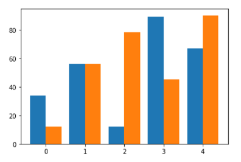

Extracted from instruction

```python
# Explore which genres dominate each community before choosing two
central['genres_list'] = central['spotify_id'].map(
    dict(zip(nodes_unique['spotify_id'], nodes_unique['genres'].apply(ast.literal_eval))))

exploded = central.explode('genres_list')

print("Top 3 genres per community:")
for c in sorted(central['community'].unique()):
    top = exploded[exploded['community'] == c]['genres_list'].value_counts().head(3)
    print("  Community %2d:" % c, ", ".join("%s (%d)" % (g, n) for g, n in top.items()))
```

```
Top 3 genres per community:
  Community  0: german hip hop (142), german underground rap (47), turkish hip hop (40)
  Community  1: turbo folk (1), dutch hip hop (1), thrash core (1)
  Community  2: classic malaysian pop (2), rock kapak (2), russian dance (1)
  Community  3: uk hip hop (132), uk drill (64), grime (54)
  Community  4: belgian hip hop (17), vlaamse rap (11), french hip hop (3)
  Community  5: dutch hip hop (261), dutch rap pop (196), dutch pop (88)
  Community  6: polish hip hop (38), polish trap (27), polish alternative rap (7)
  Community  7: dutch drill (1), dutch rap pop (1)
  Community  8: dutch pop (50), dutch rock (33), dutch hip hop (16)
  Community  9: pop urbaine (179), french hip hop (155), rap francais (116)
  Community 10: dutch rap pop (2), dutch trap (1), ukg revival (1)
  Community 11: electro house (111), edm (91), pop dance (87)
  Community 12: singer-songwriter (4), reggae (4), country (3)
  Community 13: dubstep (16), gaming dubstep (15), future bass (2)
  Community 14: rap (124), trap (97), pop rap (69)
  Community 15: trap latino (41), dominican pop (28), reggaeton (23)
```

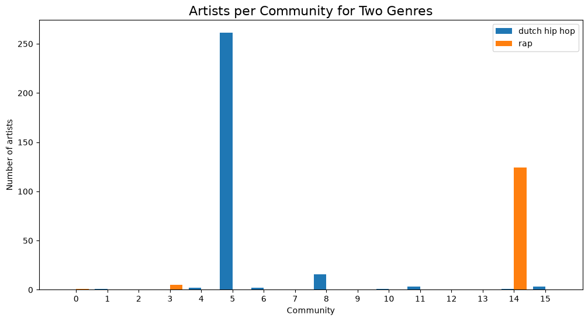

```python
# 20. Number of artists per community for two selected genres
genre_a = 'dutch hip hop'
genre_b = 'rap'

counts_a = exploded[exploded['genres_list'] == genre_a]['community'].value_counts()
counts_b = exploded[exploded['genres_list'] == genre_b]['community'].value_counts()

labels = sorted(central['community'].unique())
values_a = [counts_a.get(c, 0) for c in labels]   # .get returns 0 if the genre is absent
values_b = [counts_b.get(c, 0) for c in labels]

x = np.arange(len(labels))
width = 0.4

plt.figure(figsize=(12, 6))
plt.bar(x - width/2, values_a, width, label=genre_a)
plt.bar(x + width/2, values_b, width, label=genre_b)
plt.title("Artists per Community for Two Genres", fontdict={"size": 16})
plt.xlabel("Community")
plt.ylabel("Number of artists")
plt.xticks(x, labels)
plt.legend()
plt.show()
```

## 21. Add markdown interpretation

This chart shows that the selected genres are concentrated mainly in different communities. Dutch hip hop is predominantly associated with community 5, with approximately 261 artists, while rap is concentrated in community 14 with approximately 124 artists.

Since the Louvain algorithm identifies communities based on collaboration patterns rather than genre labels, this alignment suggests that artists tend to collaborate within their musical scenes

Curiosly, community 5 is large but has relatively low average popularity, whereas community 14 has the highest average popularity and follower count. That highlights two different patterns of collaboration and audience reach within the same network